# **From the Past to the Present: How Popular is a Baby’s Name?**

## Dihella Ikapitte

The babynames dataset gives us from each year from 1880 to 2017, the number of children that have one of those names and what their sex is. The names are provided by the SSA, the Social Security Administration, of the United States. The Social Security Administration manages social security benefits and issues social security cards. There are 1,924,665 rows in the data set spanning 137 years. As time has progressed, the popularity of names has grown or lessened, so to know more about the popularity of baby names, let’s load in our packages and get to step into over a century of it.

```r
library(tidyverse)
```

```r
library(ggplot2)
library(dplyr)
library(ggthemes)
library(babynames)
```

First, I want to know the total amount of names in the dataset and split it into two categories: female and male just so I can see how many names are categorized as female or male.

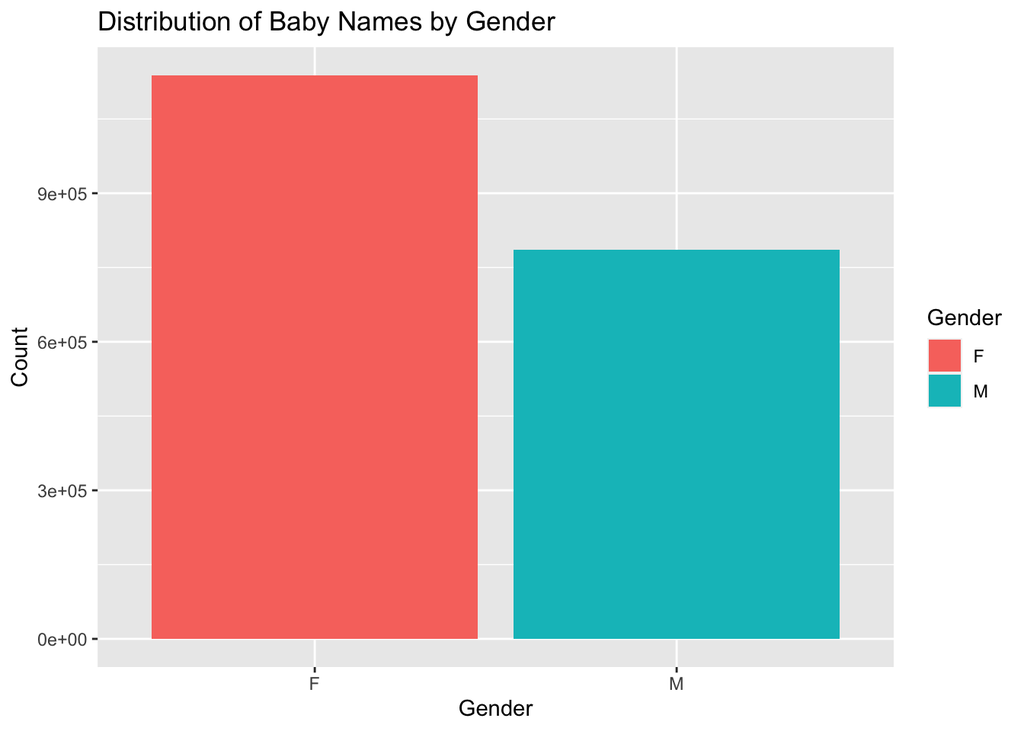

```r
# Bar chart of the total number of baby names, female and male
ggplot(babynames, aes(x = sex, fill = sex)) +
  geom_bar() +
  labs(
    title = "Distribution of Baby Names by Gender",
    x = "Gender",
    y = "Count",
    fill = "Gender"
  )
```

This bar graph shows the total number of baby names of both females and males. The sex is represented as either a “F” or “M” at the x axis and the total number of the baby names is the y axis. As the graph represents the data set, there are a high number of baby names that are female than baby names that are male, with over 900,000 names that were given to females and over 600,000 names that were given to males. Next, I want to see a specific name like Mary and filter out the name to see how prevalent the name is.

```r
babynames |>
  filter(name == "Mary")
```

```
## # A tibble: 268 × 5
##     year sex   name      n     prop
##    <dbl> <chr> <chr> <int>    <dbl>
##  1  1880 F     Mary   7065 0.0724
##  2  1880 M     Mary     27 0.000228
##  3  1881 F     Mary   6919 0.0700
##  4  1881 M     Mary     29 0.000268
##  5  1882 F     Mary   8148 0.0704
##  6  1882 M     Mary     30 0.000246
##  7  1883 F     Mary   8012 0.0667
##  8  1883 M     Mary     32 0.000284
##  9  1884 F     Mary   9217 0.0670
## 10  1884 M     Mary     36 0.000293
## # ℹ 258 more rows
```

This table shows the year, sex, and number of people with the name Mary. What is interesting is that there are males that are named Mary, which I didn’t expect in this dataset. I want to see the popularity of the name from 1880 to 2017 to see if the name has lost or gained popularity for either sex, so let’s make a line plot with the name “Mary” as an example.

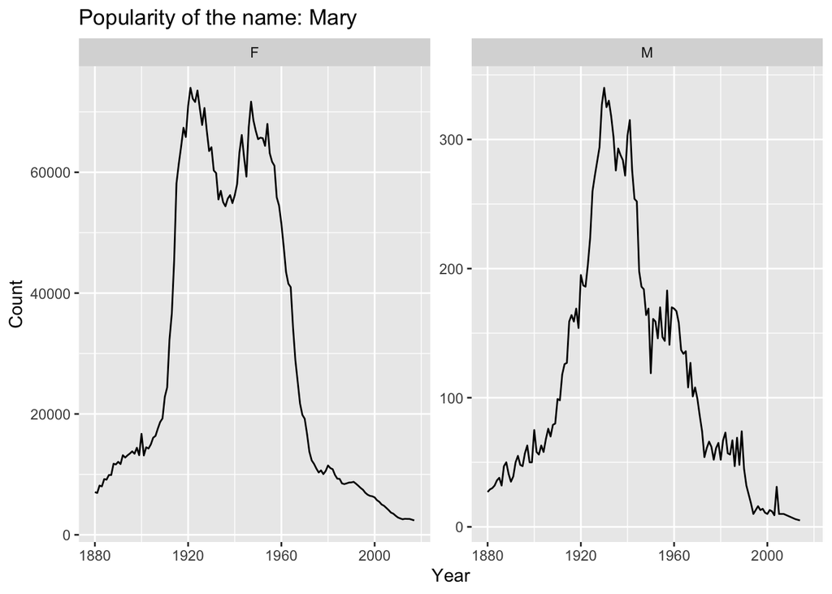

```r
# line plot of the popularity of the name "Mary"
babynames |>
  filter(name == "Mary") |>
  ggplot(aes(x = year, y = n)) +
  geom_line() +
  facet_wrap(~sex, scale = "free_y") +
  labs(
    title = "Popularity of the name: Mary",
    x = "Year",
    y = "Count"
)
```

```r
babynames |>
  filter(name == "John")
```

```
## # A tibble: 276 × 5
##     year sex   name      n     prop
##    <dbl> <chr> <chr> <int>    <dbl>
##  1  1880 F     John     46 0.000471
##  2  1880 M     John   9655 0.0815
##  3  1881 F     John     26 0.000263
##  4  1881 M     John   8769 0.0810
##  5  1882 F     John     40 0.000346
##  6  1882 M     John   9557 0.0783
##  7  1883 F     John     40 0.000333
##  8  1883 M     John   8894 0.0791
##  9  1884 F     John     40 0.000291
## 10  1884 M     John   9388 0.0765
## # ℹ 266 more rows
```

Like the filtering of the name “Mary”, there are females named John, so let’s also make another line plot to see how popular the name has become throughout time with both sexes.

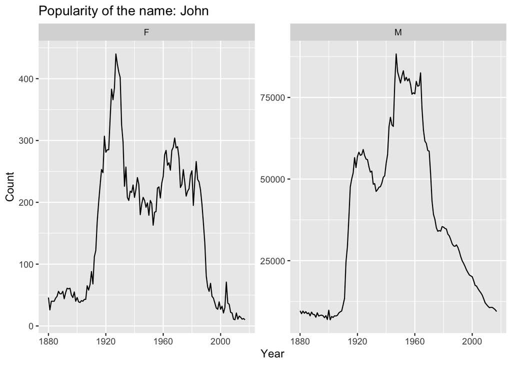

```r
# line plot of the popularity of the name "John"
babynames |>
  filter(name == "John") |>
  ggplot(aes(x = year, y = n)) +
  geom_line() +
  facet_wrap(~sex, scale = "free_y") +
  labs(
    title = "Popularity of the name: John",
    x = "Year",
    y = "Count"
)
```

# Conclusion

The line plots of the babynames package show the rise and fall of two names and the number of males and females were given that name. For the plots for the name Mary, there was more popularity with female babies than with male babies. For the line plots for the name John, the popularity of the name was higher for males than it was for females. One reason that is possible for both is because Mary is a feminine name, so it is highly common for parents to name their female babies Mary instead of naming their male baby Mary. It is the same for John; it is a traditional masculine name, so it is uncommon for parents to name their female baby John. the There could be possible limitations with this data set. One would be since it starts in 1880, if some of the information could be outdated, could be false, and haven’t updated. Alongside the dataset possibly not being updated, it might not capture all the names, for example, different spelling of names or rare/uncommon names, so it might affect the plots if I used different names.